# Risk Factor Analysis

## Outcome Variable

**Outcome Variable:** sstunted

## Predictor Variables

**Intervention Variable:** nchldlt5

**Adjustment Set:**

- arm
- W_mage
- meducyrs
- feducyrs
- hhwealth_quart
- hfoodsec
- W_mhtcm
- W_mwtkg
- W_mbmi
- W_nrooms
- W_parity
- impfloor
- impsan
- safeh20
- delta_W_mage
- delta_meducyrs
- delta_feducyrs
- delta_hhwealth_quart
- delta_hfoodsec
- delta_W_mhtcm
- delta_W_mwtkg
- delta_W_mbmi
- delta_W_nrooms
- delta_W_parity
- delta_impfloor
- delta_impsan
- delta_safeh20

## Stratifying Variables

The analysis was stratified on these variable(s):

- agecat
- studyid
- country

## Data Summary

| agecat | studyid | country | nchldlt5 | sstunted | n_cell | n |
| --- | --- | --- | --- | --- | --- | --- |
| Birth | IRC | INDIA | 1 | 0 | 79 | 388 |
| Birth | IRC | INDIA | 1 | 1 | 5 | 388 |
| Birth | IRC | INDIA | 2+ | 0 | 293 | 388 |
| Birth | IRC | INDIA | 2+ | 1 | 11 | 388 |
| Birth | JiVitA-3 | BANGLADESH | 1 | 0 | 12217 | 22431 |
| Birth | JiVitA-3 | BANGLADESH | 1 | 1 | 1769 | 22431 |
| Birth | JiVitA-3 | BANGLADESH | 2+ | 0 | 7766 | 22431 |
| Birth | JiVitA-3 | BANGLADESH | 2+ | 1 | 679 | 22431 |
| Birth | NIH-Crypto | BANGLADESH | 1 | 0 | 515 | 732 |
| Birth | NIH-Crypto | BANGLADESH | 1 | 1 | 7 | 732 |
| Birth | NIH-Crypto | BANGLADESH | 2+ | 0 | 207 | 732 |
| Birth | NIH-Crypto | BANGLADESH | 2+ | 1 | 3 | 732 |
| Birth | PROVIDE | BANGLADESH | 1 | 0 | 388 | 539 |
| Birth | PROVIDE | BANGLADESH | 1 | 1 | 3 | 539 |
| Birth | PROVIDE | BANGLADESH | 2+ | 0 | 147 | 539 |
| Birth | PROVIDE | BANGLADESH | 2+ | 1 | 1 | 539 |
| 6 months | IRC | INDIA | 1 | 0 | 78 | 407 |
| 6 months | IRC | INDIA | 1 | 1 | 11 | 407 |
| 6 months | IRC | INDIA | 2+ | 0 | 300 | 407 |
| 6 months | IRC | INDIA | 2+ | 1 | 18 | 407 |
| 6 months | JiVitA-3 | BANGLADESH | 1 | 0 | 10177 | 16800 |
| 6 months | JiVitA-3 | BANGLADESH | 1 | 1 | 710 | 16800 |
| 6 months | JiVitA-3 | BANGLADESH | 2+ | 0 | 5604 | 16800 |
| 6 months | JiVitA-3 | BANGLADESH | 2+ | 1 | 309 | 16800 |
| 6 months | LCNI-5 | MALAWI | 1 | 0 | 362 | 811 |
| 6 months | LCNI-5 | MALAWI | 1 | 1 | 28 | 811 |
| 6 months | LCNI-5 | MALAWI | 2+ | 0 | 384 | 811 |
| 6 months | LCNI-5 | MALAWI | 2+ | 1 | 37 | 811 |
| 6 months | NIH-Crypto | BANGLADESH | 1 | 0 | 492 | 715 |
| 6 months | NIH-Crypto | BANGLADESH | 1 | 1 | 15 | 715 |
| 6 months | NIH-Crypto | BANGLADESH | 2+ | 0 | 200 | 715 |
| 6 months | NIH-Crypto | BANGLADESH | 2+ | 1 | 8 | 715 |
| 6 months | PROVIDE | BANGLADESH | 1 | 0 | 428 | 604 |
| 6 months | PROVIDE | BANGLADESH | 1 | 1 | 10 | 604 |
| 6 months | PROVIDE | BANGLADESH | 2+ | 0 | 162 | 604 |
| 6 months | PROVIDE | BANGLADESH | 2+ | 1 | 4 | 604 |
| 6 months | TanzaniaChild2 | TANZANIA, UNITED REPUBLIC OF | 1 | 0 | 1384 | 2020 |
| 6 months | TanzaniaChild2 | TANZANIA, UNITED REPUBLIC OF | 1 | 1 | 7 | 2020 |
| 6 months | TanzaniaChild2 | TANZANIA, UNITED REPUBLIC OF | 2+ | 0 | 617 | 2020 |
| 6 months | TanzaniaChild2 | TANZANIA, UNITED REPUBLIC OF | 2+ | 1 | 12 | 2020 |
| 24 months | IRC | INDIA | 1 | 0 | 82 | 409 |
| 24 months | IRC | INDIA | 1 | 1 | 7 | 409 |
| 24 months | IRC | INDIA | 2+ | 0 | 286 | 409 |
| 24 months | IRC | INDIA | 2+ | 1 | 34 | 409 |
| 24 months | JiVitA-3 | BANGLADESH | 1 | 0 | 4671 | 8622 |
| 24 months | JiVitA-3 | BANGLADESH | 1 | 1 | 783 | 8622 |
| 24 months | JiVitA-3 | BANGLADESH | 2+ | 0 | 2607 | 8622 |
| 24 months | JiVitA-3 | BANGLADESH | 2+ | 1 | 561 | 8622 |
| 24 months | LCNI-5 | MALAWI | 1 | 0 | 255 | 571 |
| 24 months | LCNI-5 | MALAWI | 1 | 1 | 28 | 571 |
| 24 months | LCNI-5 | MALAWI | 2+ | 0 | 247 | 571 |
| 24 months | LCNI-5 | MALAWI | 2+ | 1 | 41 | 571 |
| 24 months | NIH-Crypto | BANGLADESH | 1 | 0 | 336 | 514 |
| 24 months | NIH-Crypto | BANGLADESH | 1 | 1 | 21 | 514 |
| 24 months | NIH-Crypto | BANGLADESH | 2+ | 0 | 142 | 514 |
| 24 months | NIH-Crypto | BANGLADESH | 2+ | 1 | 15 | 514 |
| 24 months | PROVIDE | BANGLADESH | 1 | 0 | 389 | 578 |
| 24 months | PROVIDE | BANGLADESH | 1 | 1 | 35 | 578 |
| 24 months | PROVIDE | BANGLADESH | 2+ | 0 | 137 | 578 |
| 24 months | PROVIDE | BANGLADESH | 2+ | 1 | 17 | 578 |
| 24 months | TanzaniaChild2 | TANZANIA, UNITED REPUBLIC OF | 1 | 0 | 4 | 6 |
| 24 months | TanzaniaChild2 | TANZANIA, UNITED REPUBLIC OF | 1 | 1 | 1 | 6 |
| 24 months | TanzaniaChild2 | TANZANIA, UNITED REPUBLIC OF | 2+ | 0 | 1 | 6 |
| 24 months | TanzaniaChild2 | TANZANIA, UNITED REPUBLIC OF | 2+ | 1 | 0 | 6 |

The following strata were considered:

- agecat: 24 months, studyid: IRC, country: INDIA
- agecat: 24 months, studyid: JiVitA-3, country: BANGLADESH
- agecat: 24 months, studyid: LCNI-5, country: MALAWI
- agecat: 24 months, studyid: NIH-Crypto, country: BANGLADESH
- agecat: 24 months, studyid: PROVIDE, country: BANGLADESH
- agecat: 24 months, studyid: TanzaniaChild2, country: TANZANIA, UNITED REPUBLIC OF
- agecat: 6 months, studyid: IRC, country: INDIA
- agecat: 6 months, studyid: JiVitA-3, country: BANGLADESH
- agecat: 6 months, studyid: LCNI-5, country: MALAWI
- agecat: 6 months, studyid: NIH-Crypto, country: BANGLADESH
- agecat: 6 months, studyid: PROVIDE, country: BANGLADESH
- agecat: 6 months, studyid: TanzaniaChild2, country: TANZANIA, UNITED REPUBLIC OF
- agecat: Birth, studyid: IRC, country: INDIA
- agecat: Birth, studyid: JiVitA-3, country: BANGLADESH
- agecat: Birth, studyid: NIH-Crypto, country: BANGLADESH
- agecat: Birth, studyid: PROVIDE, country: BANGLADESH

### Dropped Strata

Some strata were dropped due to rare outcomes:

- agecat: Birth, studyid: NIH-Crypto, country: BANGLADESH
- agecat: Birth, studyid: PROVIDE, country: BANGLADESH
- agecat: 6 months, studyid: PROVIDE, country: BANGLADESH
- agecat: 24 months, studyid: TanzaniaChild2, country: TANZANIA, UNITED REPUBLIC OF

## Methods Detail

We’re interested in the causal parameters $E[Y_a]$ for all values of $a \in \mathcal{A}$. These parameters represent the mean outcome if, possibly contrary to fact, we intervened to set all units to have $A=a$. Under the randomization and positivity assumptions, these are identified by the statistical parameters $\psi_a=E_W[E_{Y|A,W}(Y|A=a,W)]$. In addition, we’re interested in the mean of $Y$, $E[Y]$ under no intervention (the observed mean). We will estimate these parameters by using SuperLearner to fit the relevant likelihood factors – $E_{Y|A,W}(Y|A=a,W)$ and $p(A=a|W)$, and then updating our likelihood fit using a joint TMLE.

For unadjusted analyses ($W=\{\}$), initial likelihoods were estimated using Lrnr_glm to estimate the simple $E(Y|A)$ and Lrnr_mean to estimate $p(A)$. For adjusted analyses, a small library containing Lrnr_glmnet, Lrnr_xgboost, and Lrnr_mean was used.

Having estimated these parameters, we will then use the delta method to estimate relative risks and attributable risks relative to a prespecified baseline level of $A$.

# Results Detail

## Results Plots

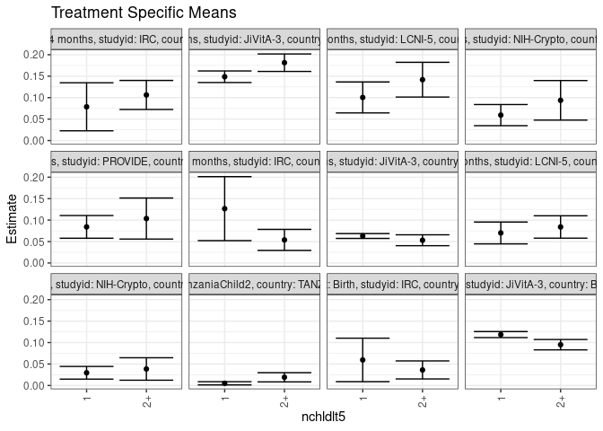

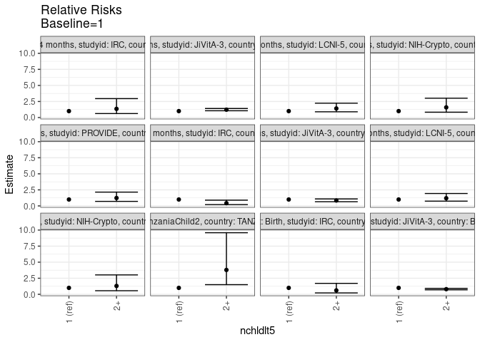

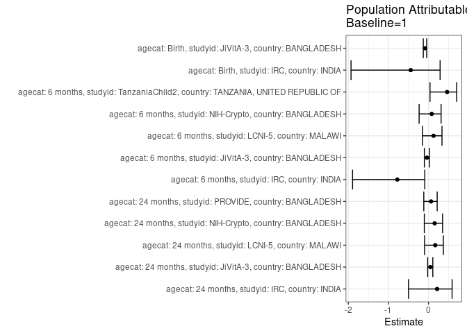

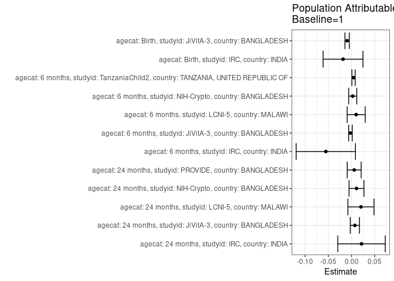

## Results Table

### Parameter: TSM

| agecat | studyid | country | intervention_level | baseline_level | estimate | ci_lower | ci_upper |
| --- | --- | --- | --- | --- | --- | --- | --- |
| Birth | IRC | INDIA | 1 | NA | 0.0595238 | 0.0088611 | 0.1101865 |
| Birth | IRC | INDIA | 2+ | NA | 0.0361842 | 0.0151644 | 0.0572040 |
| Birth | JiVitA-3 | BANGLADESH | 1 | NA | 0.1185874 | 0.1115619 | 0.1256129 |
| Birth | JiVitA-3 | BANGLADESH | 2+ | NA | 0.0950341 | 0.0829665 | 0.1071016 |
| 6 months | IRC | INDIA | 1 | NA | 0.1266851 | 0.0521201 | 0.2012502 |
| 6 months | IRC | INDIA | 2+ | NA | 0.0538688 | 0.0294018 | 0.0783358 |
| 6 months | JiVitA-3 | BANGLADESH | 1 | NA | 0.0629388 | 0.0573039 | 0.0685737 |
| 6 months | JiVitA-3 | BANGLADESH | 2+ | NA | 0.0530488 | 0.0403852 | 0.0657124 |
| 6 months | LCNI-5 | MALAWI | 1 | NA | 0.0700524 | 0.0445951 | 0.0955097 |
| 6 months | LCNI-5 | MALAWI | 2+ | NA | 0.0839920 | 0.0579129 | 0.1100711 |
| 6 months | NIH-Crypto | BANGLADESH | 1 | NA | 0.0295858 | 0.0148264 | 0.0443452 |
| 6 months | NIH-Crypto | BANGLADESH | 2+ | NA | 0.0384615 | 0.0123088 | 0.0646143 |
| 6 months | TanzaniaChild2 | TANZANIA, UNITED REPUBLIC OF | 1 | NA | 0.0050324 | 0.0013129 | 0.0087518 |
| 6 months | TanzaniaChild2 | TANZANIA, UNITED REPUBLIC OF | 2+ | NA | 0.0190779 | 0.0083846 | 0.0297712 |
| 24 months | IRC | INDIA | 1 | NA | 0.0786517 | 0.0226565 | 0.1346469 |
| 24 months | IRC | INDIA | 2+ | NA | 0.1062500 | 0.0724453 | 0.1400547 |
| 24 months | JiVitA-3 | BANGLADESH | 1 | NA | 0.1486517 | 0.1351777 | 0.1621258 |
| 24 months | JiVitA-3 | BANGLADESH | 2+ | NA | 0.1814109 | 0.1610486 | 0.2017731 |
| 24 months | LCNI-5 | MALAWI | 1 | NA | 0.1004530 | 0.0643791 | 0.1365269 |
| 24 months | LCNI-5 | MALAWI | 2+ | NA | 0.1418209 | 0.1013451 | 0.1822968 |
| 24 months | NIH-Crypto | BANGLADESH | 1 | NA | 0.0592854 | 0.0346588 | 0.0839119 |
| 24 months | NIH-Crypto | BANGLADESH | 2+ | NA | 0.0937078 | 0.0476063 | 0.1398093 |
| 24 months | PROVIDE | BANGLADESH | 1 | NA | 0.0841598 | 0.0576865 | 0.1106332 |
| 24 months | PROVIDE | BANGLADESH | 2+ | NA | 0.1036540 | 0.0558625 | 0.1514455 |

### Parameter: E(Y)

| agecat | studyid | country | intervention_level | baseline_level | estimate | ci_lower | ci_upper |
| --- | --- | --- | --- | --- | --- | --- | --- |
| Birth | IRC | INDIA | NA | NA | 0.0412371 | 0.0214268 | 0.0610475 |
| Birth | JiVitA-3 | BANGLADESH | NA | NA | 0.1091347 | 0.1045757 | 0.1136937 |
| 6 months | IRC | INDIA | NA | NA | 0.0712531 | 0.0462303 | 0.0962759 |
| 6 months | JiVitA-3 | BANGLADESH | NA | NA | 0.0606548 | 0.0568002 | 0.0645093 |
| 6 months | LCNI-5 | MALAWI | NA | NA | 0.0801480 | 0.0614493 | 0.0988466 |
| 6 months | NIH-Crypto | BANGLADESH | NA | NA | 0.0321678 | 0.0192256 | 0.0451101 |
| 6 months | TanzaniaChild2 | TANZANIA, UNITED REPUBLIC OF | NA | NA | 0.0094059 | 0.0051955 | 0.0136164 |
| 24 months | IRC | INDIA | NA | NA | 0.1002445 | 0.0711031 | 0.1293859 |
| 24 months | JiVitA-3 | BANGLADESH | NA | NA | 0.1558803 | 0.1471449 | 0.1646158 |
| 24 months | LCNI-5 | MALAWI | NA | NA | 0.1208406 | 0.0940828 | 0.1475985 |
| 24 months | NIH-Crypto | BANGLADESH | NA | NA | 0.0700389 | 0.0479542 | 0.0921236 |
| 24 months | PROVIDE | BANGLADESH | NA | NA | 0.0899654 | 0.0666186 | 0.1133122 |

### Parameter: RR

| agecat | studyid | country | intervention_level | baseline_level | estimate | ci_lower | ci_upper |
| --- | --- | --- | --- | --- | --- | --- | --- |
| Birth | IRC | INDIA | 1 | 1 | 1.0000000 | 1.0000000 | 1.0000000 |
| Birth | IRC | INDIA | 2+ | 1 | 0.6078947 | 0.2169190 | 1.7035666 |
| Birth | JiVitA-3 | BANGLADESH | 1 | 1 | 1.0000000 | 1.0000000 | 1.0000000 |
| Birth | JiVitA-3 | BANGLADESH | 2+ | 1 | 0.8013841 | 0.6958563 | 0.9229155 |
| 6 months | IRC | INDIA | 1 | 1 | 1.0000000 | 1.0000000 | 1.0000000 |
| 6 months | IRC | INDIA | 2+ | 1 | 0.4252180 | 0.2020971 | 0.8946709 |
| 6 months | JiVitA-3 | BANGLADESH | 1 | 1 | 1.0000000 | 1.0000000 | 1.0000000 |
| 6 months | JiVitA-3 | BANGLADESH | 2+ | 1 | 0.8428637 | 0.6535701 | 1.0869824 |
| 6 months | LCNI-5 | MALAWI | 1 | 1 | 1.0000000 | 1.0000000 | 1.0000000 |
| 6 months | LCNI-5 | MALAWI | 2+ | 1 | 1.1989882 | 0.7430684 | 1.9346439 |
| 6 months | NIH-Crypto | BANGLADESH | 1 | 1 | 1.0000000 | 1.0000000 | 1.0000000 |
| 6 months | NIH-Crypto | BANGLADESH | 2+ | 1 | 1.3000000 | 0.5593501 | 3.0213633 |
| 6 months | TanzaniaChild2 | TANZANIA, UNITED REPUBLIC OF | 1 | 1 | 1.0000000 | 1.0000000 | 1.0000000 |
| 6 months | TanzaniaChild2 | TANZANIA, UNITED REPUBLIC OF | 2+ | 1 | 3.7910516 | 1.4993541 | 9.5855087 |
| 24 months | IRC | INDIA | 1 | 1 | 1.0000000 | 1.0000000 | 1.0000000 |
| 24 months | IRC | INDIA | 2+ | 1 | 1.3508929 | 0.6193830 | 2.9463377 |
| 24 months | JiVitA-3 | BANGLADESH | 1 | 1 | 1.0000000 | 1.0000000 | 1.0000000 |
| 24 months | JiVitA-3 | BANGLADESH | 2+ | 1 | 1.2203752 | 1.0574927 | 1.4083461 |
| 24 months | LCNI-5 | MALAWI | 1 | 1 | 1.0000000 | 1.0000000 | 1.0000000 |
| 24 months | LCNI-5 | MALAWI | 2+ | 1 | 1.4118141 | 0.8919680 | 2.2346308 |
| 24 months | NIH-Crypto | BANGLADESH | 1 | 1 | 1.0000000 | 1.0000000 | 1.0000000 |
| 24 months | NIH-Crypto | BANGLADESH | 2+ | 1 | 1.5806232 | 0.8303208 | 3.0089207 |
| 24 months | PROVIDE | BANGLADESH | 1 | 1 | 1.0000000 | 1.0000000 | 1.0000000 |
| 24 months | PROVIDE | BANGLADESH | 2+ | 1 | 1.2316330 | 0.7060664 | 2.1484096 |

### Parameter: PAR

| agecat | studyid | country | intervention_level | baseline_level | estimate | ci_lower | ci_upper |
| --- | --- | --- | --- | --- | --- | --- | --- |
| Birth | IRC | INDIA | 1 | NA | -0.0182867 | -0.0612727 | 0.0246993 |
| Birth | JiVitA-3 | BANGLADESH | 1 | NA | -0.0094527 | -0.0141345 | -0.0047710 |
| 6 months | IRC | INDIA | 1 | NA | -0.0554321 | -0.1193683 | 0.0085042 |
| 6 months | JiVitA-3 | BANGLADESH | 1 | NA | -0.0022840 | -0.0061363 | 0.0015683 |
| 6 months | LCNI-5 | MALAWI | 1 | NA | 0.0100955 | -0.0093638 | 0.0295549 |
| 6 months | NIH-Crypto | BANGLADESH | 1 | NA | 0.0025820 | -0.0061590 | 0.0113231 |
| 6 months | TanzaniaChild2 | TANZANIA, UNITED REPUBLIC OF | 1 | NA | 0.0043736 | 0.0008368 | 0.0079104 |
| 24 months | IRC | INDIA | 1 | NA | 0.0215928 | -0.0295941 | 0.0727798 |
| 24 months | JiVitA-3 | BANGLADESH | 1 | NA | 0.0072286 | -0.0026554 | 0.0171126 |
| 24 months | LCNI-5 | MALAWI | 1 | NA | 0.0203876 | -0.0077467 | 0.0485220 |
| 24 months | NIH-Crypto | BANGLADESH | 1 | NA | 0.0107536 | -0.0053008 | 0.0268079 |
| 24 months | PROVIDE | BANGLADESH | 1 | NA | 0.0058056 | -0.0091976 | 0.0208087 |

### Parameter: PAF

| agecat | studyid | country | intervention_level | baseline_level | estimate | ci_lower | ci_upper |
| --- | --- | --- | --- | --- | --- | --- | --- |
| Birth | IRC | INDIA | 1 | NA | -0.4434524 | -1.9325479 | 0.2895070 |
| Birth | JiVitA-3 | BANGLADESH | 1 | NA | -0.0866153 | -0.1299424 | -0.0449496 |
| 6 months | IRC | INDIA | 1 | NA | -0.7779605 | -1.8939299 | -0.0923359 |
| 6 months | JiVitA-3 | BANGLADESH | 1 | NA | -0.0376559 | -0.1030241 | 0.0238384 |
| 6 months | LCNI-5 | MALAWI | 1 | NA | 0.1259613 | -0.1519715 | 0.3368381 |
| 6 months | NIH-Crypto | BANGLADESH | 1 | NA | 0.0802676 | -0.2334419 | 0.3141892 |
| 6 months | TanzaniaChild2 | TANZANIA, UNITED REPUBLIC OF | 1 | NA | 0.4649816 | 0.0380762 | 0.7024248 |
| 24 months | IRC | INDIA | 1 | NA | 0.2154015 | -0.4980614 | 0.5890724 |
| 24 months | JiVitA-3 | BANGLADESH | 1 | NA | 0.0463728 | -0.0193684 | 0.1078742 |
| 24 months | LCNI-5 | MALAWI | 1 | NA | 0.1687151 | -0.0971667 | 0.3701645 |
| 24 months | NIH-Crypto | BANGLADESH | 1 | NA | 0.1535370 | -0.1039415 | 0.3509623 |
| 24 months | PROVIDE | BANGLADESH | 1 | NA | 0.0645312 | -0.1170455 | 0.2165925 |